[figure not shown]

# Pricenow ML Challenge

## Some Important Remarks

1. You can use any built-in Python library that comes with Anaconda.
2. Be sure to provide a textual description of your thought process, the assumptions you made, the solution you implemented, and explanations for your answers. A notebook that only has code cells will not suffice.
3. We will **not run your notebook for you**! Thus, be sure to send us a **fully-run and evaluated notebook**.
4. Make sure to print results or dataframes that confirm you have properly addressed the task.
5. The points are just a rough estimation for you on how much time you should spend for each task.
6. Best of luck and feel free to reach out in case of any questions!

```python
# Imports you may need
# Feel free to import other librariers (especially for the ML parts)
import pandas as pd
import matplotlib.pyplot as plt
from matplotlib import ticker

import seaborn as sns
import numpy as np
import scipy
import itertools

# datetime operations
from datetime import datetime

# multiprocessing
from joblib import Parallel, delayed
import multiprocessing
import time

# ttest and euclidean distance
from scipy.stats import ttest_ind
from scipy.spatial.distance import seuclidean

# linear fit using statsmodels
import statsmodels.api as sm
import statsmodels.formula.api as smf

# sklearn
from sklearn.base import BaseEstimator, ClassifierMixin, RegressorMixin
from sklearn.utils.validation import check_X_y, check_array, check_is_fitted
from sklearn.utils.multiclass import unique_labels
from sklearn.metrics import euclidean_distances, r2_score
from sklearn.model_selection import train_test_split, KFold
from sklearn.preprocessing import StandardScaler
from sklearn.linear_model import LinearRegression
from sklearn.ensemble import GradientBoostingRegressor
```

## Part I - SQL

Your company recently developed a pay-per-use solution for several ski resorts in the Valais (region in Switzerland). The [**Valais Mountain Card**](https://valaismountaincard.ch/en/home) is a subscription that allows users to automatically experience the ski resorts at the best price all winter long. Based on the usage, the solution automatically calculates the best price, minus a 10% discount. While the product can already be purchased, your marketing department struggles to address the right target groups for their campagins. They have already found out that the Valais Mountain Card is especially relevant for frequent skiers and snowboarders. However, they are unable to identify this user group. They have therefore reached out to you, to help them get the relevant information.Your first task is to write some SQL queries to identify the most frequent users in the Valais ski resorts and their origin.

You are provided with a database dump. For part I, the following tables are relevant:

- `account`: contains all user accounts
- `address`: addresses and their pupose for user accounts
- `frequencies`: frequencies generated by keycards
- `keycard`: keycards and their link to a person
- `person`: individual person that belongs to a account
- `weather_daily`: daily weather forecast containing one row per day per client (only needed for task 1 d)

You can run and write the queries either in a database environment such as `DataGrip` or `DBeaver` or in this notebook using `SQLAlchemy` and `Psycopg2`

- `SQLAlchemy` generates SQL statements from python
- `Psycopg2` communicates your SQL statements to your Postgres database

Both of these packages can be installed from the command line with pip or conda:

```
pip install sqlalchemy psycopg2
conda install -y sqlalchemy psycopg2
```

In case you decide to use a database environment, just copy the raw SQL query and the result into this notebook. You can find the database credentials for the Postgres database, two cells below. In case you face issues when trying to connect to the database, feel free to reach out.

```python
# Create database engine and connection
from sqlalchemy import create_engine, text

# Postgres credentials
POSTGRES_ADDRESS = "pricenow-data-challenge.conwkcxk9ed9.eu-west-1.rds.amazonaws.com"
POSTGRES_DBNAME = "postgres"
POSTGRES_PORT = "5432"
POSTGRES_USERNAME = "viewer"
POSTGRES_PASSWORD = "tURa3/CcTFT/]qL6"

# A long string that contains the necessary Postgres login information
postgres_str = "postgresql://{username}:{password}@{ipaddress}:{port}/{dbname}".format(
    username=POSTGRES_USERNAME,
    password=POSTGRES_PASSWORD,
    ipaddress=POSTGRES_ADDRESS,
    port=POSTGRES_PORT,
    dbname=POSTGRES_DBNAME,
)

# Create the connection
cnx = create_engine(postgres_str)
```

```python
# Example on how you can query from the Postgres db and then write it to a df
pd.read_sql_query("""SELECT * FROM person LIMIT 5;""", cnx)
```

|  | id | title | firstName | middleName | lastName | gender | accountId | createdAt | updatedAt | owner | deletedAt |
| --- | --- | --- | --- | --- | --- | --- | --- | --- | --- | --- | --- |
| 0 | 736 |  | Solène | None | David | f | auth0\|61ced25a895964007308df40 | 2021-12-31 09:50:31.806 | 2021-12-31 09:50:31.807 | True | NaT |
| 1 | 194 |  | Rita | None | Carrel | m | auth0\|61b3429cc3f245006c2957ca | 2021-12-10 12:06:17.490 | 2021-12-10 12:06:17.490 | True | NaT |
| 2 | 408 |  | Fabien | None | Menzel | m | auth0\|61bf15ecd60bf4006b531ab1 | 2021-12-19 11:24:07.371 | 2021-12-19 11:24:07.372 | False | NaT |
| 3 | 188 |  | Esther | None | Profico | m | auth0\|61b31b9ffcbfe500716cf149 | 2021-12-10 09:20:24.605 | 2021-12-10 09:22:29.932 | True | NaT |
| 4 | 66 |  | Rushda | None | Berchtold | f | auth0\|61aa613b65d7430069d9b17c | 2021-12-03 18:27:02.226 | 2021-12-30 10:30:48.189 | False | 2021-12-30 10:30:48.188 |

### Task 1 a) - 8 pts

Whenever a user wants to board a mountain railroad in the ski resort, they have to present their keycard at a turnstile before being allowed to board. Every time a user scans their keycard at a turnstile, a frequency is created in the database.

Your task is now to find the 10 most frequent Valais Mountain Card users and the city they live in across all ski resorts. You can assume that all frequencies in the database belong to ski resorts that are part of the Valais Mountain Card. For this task, we define the most frequent users based on their total number of frequencies. If two users have the same amount of frequencies, they should have the same rank. Some accounts may have several addresses. In this case, you are free to choose which address to use.

Your output should include the following columns: **rank, first_name, last_name, zip, city, nr_of_frequencies**

Assuming the tables mentionned above are related in the following way: `frequencies` <*dataCarrierId* and *permissionId* > `keycard` <*personId* and *id*> `person` <*accountId*> `address` we could write the following query to get the ranking by the frequencies:

```python
frequency_query = """
SELECT
    "rank",
    "firstName",
    "lastName",
    zip,
    city,
    nr_of_frequencies
FROM
    (SELECT
         p."firstName",
         p."lastName",
         a.zip,
         a.city,
         COUNT(*) AS nr_of_frequencies,
         RANK() OVER (ORDER BY COUNT(*) DESC) AS rank
     FROM
         frequencies f
         JOIN keycard k ON f.data_carrier_id = k."dataCarrierId" and f.permission_id = k."permissionId"
         JOIN person p ON k."personId" = p.id
         JOIN address a ON p."accountId" = a."accountId"
     GROUP BY
         p."firstName",
         p."lastName",
         a.zip,
         a.city
     ) subquery
WHERE
    rank <= 10;
"""
pd.read_sql_query(frequency_query, cnx)
```

|  | rank | firstName | lastName | zip | city | nr_of_frequencies |
| --- | --- | --- | --- | --- | --- | --- |
| 0 | 1 | Ignatius | Vanay | 8708 | Männedorf | 91 |
| 1 | 2 | Esther | Profico | 8708 | Männedorf | 84 |
| 2 | 3 | Marco | Romanens | 3900 | Brig | 61 |
| 3 | 4 | Anne | ROSSINI | 1004 | Lausanne | 59 |
| 4 | 4 | Maximilian | Wehner | 3074 | Muri b. Bern | 59 |
| 5 | 6 | HUTTER | Tenud | 3902 | Glis | 56 |
| 6 | 7 | Benedetto | Constantin | 1033 | Cheseaux &#x2F; Lausanne | 54 |
| 7 | 8 | Maxine | Ludi | 3110 | Münsingen | 51 |
| 8 | 9 | Zoé | Rüegg | 1920 | Martigny | 50 |
| 9 | 10 | Kurt | Steiling | 3110 | Münsingen | 49 |

### Task 1 b) - 6 pts

[Bluebird days](https://www.coloradoski.com/blog/skiers-vocabulary-where-ski-terms-come) not only offer excellent skiing conditions, they are also the days when you can charge higher ticket prices. Your task is to find the bluebird days for all of Pricenow's clients.

We define a bluebird day as the following:

- at least 10cm of fresh snow during the previous (!!) day
- at least 70% relative sunshine

In this task we assume the the column `avg_precipitation` correspond to the average amount of fresh snow. In this case we could write the following query to identify the bluebird days.

```python
weather_query = """
SELECT
    client_id,
    date,
    rel_sunshine,
    avg_precipitation
FROM
    weather_daily wd
WHERE
    EXISTS (
        SELECT
            1
        FROM
            weather_daily wd2
        WHERE
            wd.client_id = wd2.client_id
            AND wd2.date = wd.date - interval '1 day'
            AND wd2.avg_precipitation >= 0.1
    )
    AND rel_sunshine >= 0.7
"""
pd.read_sql_query(weather_query, cnx)
```

|  | client_id | date | rel_sunshine | avg_precipitation |
| --- | --- | --- | --- | --- |
| 0 | 5.0 | 2022-01-06 | 0.986867 | 0.0 |
| 1 | 1.0 | 2022-01-06 | 0.837121 | 0.0 |
| 2 | 6.0 | 2022-01-07 | 0.709677 | 0.0 |
| 3 | 2.0 | 2022-01-06 | 0.932203 | 0.0 |

## Part II - Guided ML Pipeline - Will this album be a hit?

The first project you embark on in your new job is to build a regressor to predict whether an album will be well received or not. According to your boss, this algorithm may eventually be helpful in forecasting the success of albums produced by your company.

### Task 2 a) Initial Analyses — 10 pts

As a good data scientist, the first thing you do is to have a good look at the data that was handed to you.

1. Load the data using `pandas`. Identify and remove duplicate reviews, i.e., two reviews with albums by the same band with the same name (keep the first occurrence). Print the number of rows in your dataframe.
2. Plot the distribution of album release years and the average score of albums per year.
3. For numerical columns, calculate the mean, median, minimum value and maximum value. Additionally, plot the distribution for all the numerical columns in a single image.
4. For the `genre` column, assign the value `'Other'` for albums where the value is either `'none'` or `NaN`.

```python
df = pd.read_csv("data/pitchfork.csv")
df.head()
```

|  | artist | album | reviewauthor | score | releaseyear | reviewdate | recordlabel | genre | danceability | energy | key | loudness | speechiness | acousticness | instrumentalness | liveness | valence | tempo |
| --- | --- | --- | --- | --- | --- | --- | --- | --- | --- | --- | --- | --- | --- | --- | --- | --- | --- | --- |
| 0 | Studio 1 | Studio 1 | Andy Battaglia | 8.5 | 2009.0 | February 18 2009 | Studio | Electronic | 0.511917 | 0.499667 | 5.250000 | -5.626583 | 0.031983 | 0.724917 | 0.024493 | 0.165367 | 0.555083 | 101.395167 |
| 1 | John Fahey | The Great Santa Barbara Oil Slick | Mark Richardson | 8.2 | 2005.0 | February 13 2005 | Water | Folk/Country | 0.369765 | 0.325412 | 4.470588 | -19.153824 | 0.148624 | 0.647053 | 0.559133 | 0.527782 | 0.179465 | 107.622647 |
| 2 | Reigning Sound | Too Much Guitar | Stephen M. Deusner | 8.3 | 2004.0 | August 19 2004 | In the Red | Electronic | 0.253943 | 0.912857 | 4.428571 | -1.089500 | 0.055500 | 0.000253 | 0.751214 | 0.199071 | 0.552786 | 133.895500 |
| 3 | The Red Thread | After the Last | Chris Dahlen | 7.3 | 2003.0 | July 17 2003 | Badman | Rock | 0.425400 | 0.433474 | 5.700000 | -12.871000 | 0.028260 | 0.310325 | 0.224137 | 0.125150 | 0.451400 | 104.354200 |
| 4 | Mac Miller | Swimming | Evan Rytlewski | 7.5 | 2018.0 | August 3 2018 | Warner Bros. | Rap | 0.624846 | 0.438154 | 4.153846 | -9.456077 | 0.170246 | 0.652462 | 0.012819 | 0.121131 | 0.281138 | 122.121308 |

## 1. Identify and remove duplicate reviews, i.e., two reviews with albums by the same band with the same name (keep the first occurrence).

```python
def remove_duplicates(df):
    return df.drop_duplicates(subset=["artist", "album"]).reset_index(drop=True)
```

```python
df_no_duplicates = remove_duplicates(df)

# Print the number of rows in your dataframe.

print(f"Number of rows without duplicates: {df_no_duplicates.shape[0]}")
```

```
Number of rows without duplicates: 16738
```

## 2. Plot the distribution of album release years and the average score of albums per year.

```python
def plot_the_distribution(df):

    # set the figure size and style
    plt.figure(figsize=(10, 5))
    sns.set_style("darkgrid")

    # plot the distribution of release years
    sns.histplot(data=df, x="releaseyear", bins=30, kde=False)
    plt.title("Distribution of Album Release per year")
    plt.xlabel("Release Year")
    plt.ylabel("Count")
    plt.show()

    # plot the average score of albums per year
    df_avg_score_per_year = (
        df.groupby("releaseyear").agg(avg_score=("score", "mean")).reset_index()
    )

    plt.figure(figsize=(10, 5))
    sns.lineplot(data=df_avg_score_per_year, x="releaseyear", y="avg_score")
    plt.title("Average Score of Albums per year")
    plt.xlabel("Release Year")
    plt.ylabel("Average Score")
    plt.show()
```

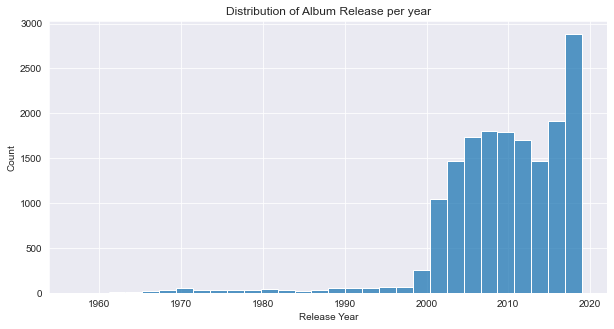

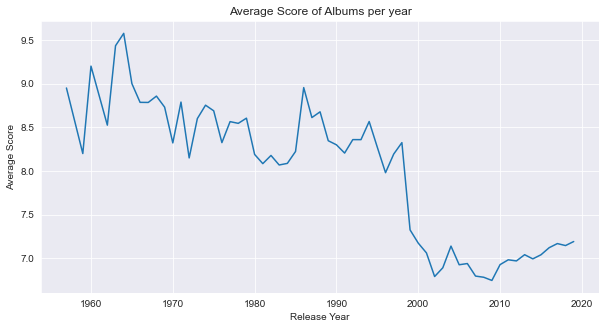

```python
plot_the_distribution(df_no_duplicates)
```

We can already see that the user behavior had changed: we see the average number of reviews grow significantly after the 2000s while the average score has dropped. It should be considered while training the model.

## 3. For numerical columns, calculate the mean, median, minimum value and maximum value.

```python
def stats_calculation(df, selected_columns):
    return (
        df[selected_columns]
        .describe()
        .loc[["mean", "50%", "min", "max"]]
        .rename({"50%": "median"})
    )
```

```python
all_numerical_columns = df.select_dtypes(include=["int", "float"]).columns.tolist()
stats_calculation(df_no_duplicates, selected_columns=all_numerical_columns)
```

|  | score | releaseyear | danceability | energy | key | loudness | speechiness | acousticness | instrumentalness | liveness | valence | tempo |
| --- | --- | --- | --- | --- | --- | --- | --- | --- | --- | --- | --- | --- |
| mean | 7.048596 | 2009.346338 | 0.512334 | 0.601276 | 5.216501 | -9.283268 | 0.090742 | 0.301914 | 0.274748 | 0.196402 | 0.405268 | 120.326487 |
| median | 7.300000 | 2010.000000 | 0.511348 | 0.624722 | 5.230769 | -8.444263 | 0.056665 | 0.228844 | 0.149363 | 0.174261 | 0.406288 | 120.397346 |
| min | 0.000000 | 1957.000000 | -1.000000 | -1.000000 | -1.000000 | -51.728750 | -1.000000 | -1.000000 | -1.000000 | -1.000000 | -1.000000 | -1.000000 |
| max | 10.000000 | 2019.000000 | 0.974000 | 0.999000 | 11.000000 | 4.078000 | 0.958000 | 0.996000 | 0.982000 | 0.978000 | 0.971000 | 215.972000 |

We can see that the median score is 7.3. It is important to note it for later sections.

## Plot the distribution of each numerical column in a single image

```python
def plot_all_distributions(df, selected_columns):
    df[selected_columns].hist(bins=20, figsize=(12, 10))
    plt.tight_layout()
    plt.show()
```

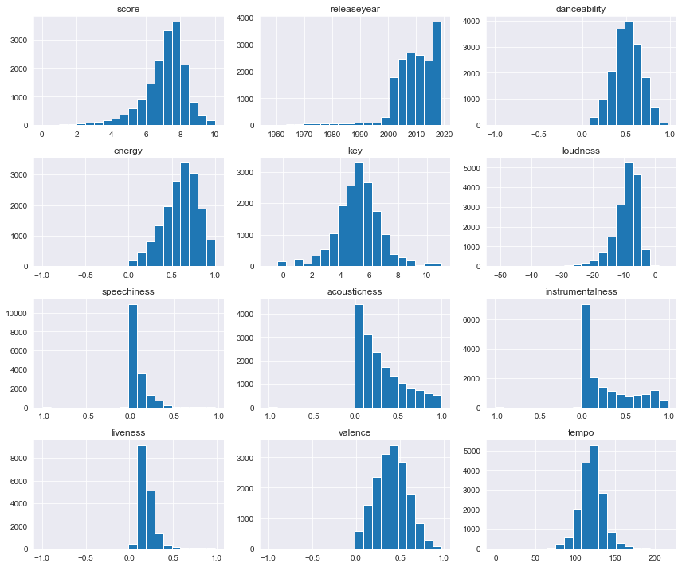

```python
plot_all_distributions(df_no_duplicates, selected_columns=all_numerical_columns)
```

## 4. For the genre column, assign the value 'Other' for albums where the value is either 'none' or NaN.

```python
def preprocess_genre_column(df):
    output = df.copy()
    output.loc[
        (output["genre"].isna()) | (output["genre"] == "none"),
        "genre",
    ] = "Other"
    return output
```

```python
df_no_duplicates = preprocess_genre_column(df_no_duplicates)
```

```python
# check genres were fixed
set(df_no_duplicates.genre)
```

```
{'Electronic',
 'Experimental',
 'Folk/Country',
 'Global',
 'Jazz',
 'Metal',
 'Other',
 'Pop/R&B',
 'Rap',
 'Rock'}
```

### Task 2 b) Pre-Processing and Pipeline Code — 6 pts

Next, you decide to prepare the code that will help you in training your machine learning models.

1. For each possible value in the `genre` column, create a new column called `{genre}_onehot` (e.g., for `genre=jazz`, create `jazz_onehot`). Collectively, these new columns should "one hot-encode" the genre column—for instance, if for a given album the `genre` is filled with the value `jazz`, the `jazz_onehot` column should equal 1 and all other `{genre}_onehot` columns should equal 0.
2. For each album, build an array of features `X` containing all genre-related one-hot features, and an array of outcomes `y` containing scores. You can use `scikit-learn` with `random_state=123` here to split the data into a train set containing 70% of all data, and a test set containing the remaining 30%.

## 1. For each possible value in the genre column, create a new column called {genre}_onehot

```python
def get_one_hot_genres(df):
    assert (
        "genre" in df.columns
    ), "Provided DataFrame doesn't contain 'genre' among its columns"
    return pd.get_dummies(df["genre"]).add_suffix("_onehot")
```

```python
one_hot = get_one_hot_genres(df_no_duplicates)
one_hot.head()
```

|  | Electronic_onehot | Experimental_onehot | Folk/Country_onehot | Global_onehot | Jazz_onehot | Metal_onehot | Other_onehot | Pop/R&B_onehot | Rap_onehot | Rock_onehot |
| --- | --- | --- | --- | --- | --- | --- | --- | --- | --- | --- |
| 0 | 1 | 0 | 0 | 0 | 0 | 0 | 0 | 0 | 0 | 0 |
| 1 | 0 | 0 | 1 | 0 | 0 | 0 | 0 | 0 | 0 | 0 |
| 2 | 1 | 0 | 0 | 0 | 0 | 0 | 0 | 0 | 0 | 0 |
| 3 | 0 | 0 | 0 | 0 | 0 | 0 | 0 | 0 | 0 | 1 |
| 4 | 0 | 0 | 0 | 0 | 0 | 0 | 0 | 0 | 1 | 0 |

## 2. For each album, build an array of features X containing all genre-related one-hot features, and an array of outcomes y containing scores. You can use scikit-learn with random_state=123 here to split the data into a train set containing 70% of all data, and a test set containing the remaining 30%.

```python
X_one_hot = one_hot
y_one_hot = df_no_duplicates["score"]
X_train, X_test, y_train, y_test = train_test_split(
    X_one_hot, y_one_hot, test_size=0.3, random_state=123
)
```

```python
X_train.head()
```

|  | Electronic_onehot | Experimental_onehot | Folk/Country_onehot | Global_onehot | Jazz_onehot | Metal_onehot | Other_onehot | Pop/R&B_onehot | Rap_onehot | Rock_onehot |
| --- | --- | --- | --- | --- | --- | --- | --- | --- | --- | --- |
| 11529 | 0 | 0 | 0 | 0 | 0 | 0 | 0 | 0 | 0 | 1 |
| 15375 | 0 | 0 | 1 | 0 | 0 | 0 | 0 | 0 | 0 | 0 |
| 13037 | 0 | 1 | 0 | 0 | 0 | 0 | 0 | 0 | 0 | 0 |
| 3019 | 0 | 1 | 0 | 0 | 0 | 0 | 0 | 0 | 0 | 0 |
| 14307 | 0 | 0 | 0 | 0 | 0 | 0 | 0 | 0 | 0 | 1 |

### Task 2 c) Regression — 18 pts

Finally, you get down to business and train your regression models.

1. Build a Linear Regression model (use `sklearn`) that predicts the outcome `score` using the features "releaseyear", "key", "acousticness", "danceability", "energy", "instrumentalness", "liveness", "loudness", "speechiness", "valence", "tempo" and the one-hot encoded genre-related columns. Using a 70/30 train-test split similar to what you did in task two (hereinafter referred to as "the random split", use the same random seed, `random_state=123`), report the $R^2$ for the testing set.
2. Create an alternate train-test split (hereinafter referred to as "the longitudinal split") where you train with data from albums released before 2000 and test with data from 2003 and after. Report the $R^2$ for the testing set using the same model you developed for the previous question. Give the correct interpretation of $R^2$ value for the longitudinal split.
3. For a given entry $X$ your model outputs a predicted score $Y'$. The difference between the real score $Y$ and the predicted score $Y'$ is called the "residual". Considering the model trained in 2c) 2. , plot the distribution of your residuals for the test set. Additionally, estimate what is the probability that your score prediction (from 2c) 2.) is off by more than 2-points? Provide bootstrapped confidence intervals for your answer.
4. Experiment with training a different regressor, a Gradient Boosting Regressor. Train the regressor using the longitudinal split and the same features as in 2c) 2., use the default hyperparameters. Report the $R^2$ for the testing set.

## 1. Build a Linear Regression model (use sklearn) that predicts the outcome score using the features "releaseyear", "key", "acousticness", "danceability", "energy", "instrumentalness", "liveness", "loudness", "speechiness", "valence", "tempo" and the one-hot encoded genre-related columns. Using a 70/30 train-test split similar to what you did in task two (hereinafter referred to as "the random split", use the same random seed, random_state=123), report the $𝑅^2$ for the testing set.

```python
def fit_model(X_train, y_train, X_test, y_test, scale=False, linear_model=True):
    X_train, y_train = X_train.copy(), y_train.copy()
    X_test, y_test = X_test.copy(), y_test.copy()
    if scale:
        # Initialize StandardScaler object
        scaler = StandardScaler()

        # Fit and transform the feature set
        X_train = scaler.fit_transform(X_train)
        X_test = scaler.transform(X_test)

    if linear_model:
        print("Using LinearRegression model")
        model = LinearRegression()
    else:
        print("Using GradientBoostingRegressor model")
        model = GradientBoostingRegressor()

    model.fit(X_train, y_train)

    # Predict scores for testing data
    y_pred = model.predict(X_test)

    # Compute r2 score of predictions
    r2 = r2_score(y_test, y_pred)

    # Print model r2 score
    print("R-squared score:", r2)
    return model
```

```python
# Compose train and test sets
music_features = [
    "releaseyear",
    "key",
    "acousticness",
    "danceability",
    "energy",
    "instrumentalness",
    "liveness",
    "loudness",
    "speechiness",
    "valence",
    "tempo",
]
one_hot_columns = list(one_hot.columns)
selected_features = music_features + one_hot_columns
df_merged = pd.concat([df_no_duplicates, one_hot], axis=1)

X = df_merged[selected_features]
y = df_merged["score"]

X_train, X_test, y_train, y_test = train_test_split(
    X, y, test_size=0.3, random_state=123
)

_ = fit_model(
    X_train=X_train,
    y_train=y_train,
    X_test=X_test,
    y_test=y_test,
    scale=True,
)

# Check columns
print(f"\nFeatures used for model fit:\n {list(X_train.columns)}")
print(f"\nFeatures used for prediction:\n {list(X_test.columns)}")
```

[output not shown]

Regarding the $R^2$ score we might think that linear model is not the best choice for given data.

## 2. Create an alternate train-test split (hereinafter referred to as "the longitudinal split") where you train with data from albums released before 2000 and test with data from 2003 and after. Report the 𝑅2 for the testing set using the same model you developed for the previous question. Give the correct interpretation of $𝑅^2$ value for the longitudinal split.

```python
data_before_2000 = df_merged[df_merged["releaseyear"] < 2000]
data_after_2003 = df_merged[df_merged["releaseyear"] >= 2003]
X_longitudinal_train, y_longitudinal_train = (
    data_before_2000[selected_features],
    data_before_2000["score"],
)
X_longitudinal_test, y_longitudinal_test = (
    data_after_2003[selected_features],
    data_after_2003["score"],
)
```

```python
_ = fit_model(
    X_train=X_longitudinal_train,
    y_train=y_longitudinal_train,
    X_test=X_longitudinal_test,
    y_test=y_longitudinal_test,
    scale=True,
)
```

[output not shown]

```python
# Check columns
print(f"\nFeatures used for model fit:\n {list(X_longitudinal_train.columns)}")
print(f"\nFeatures used for prediction:\n {list(X_longitudinal_test.columns)}")
```

```
Features used for model fit:
 ['releaseyear', 'key', 'acousticness', 'danceability', 'energy', 'instrumentalness', 'liveness', 'loudness', 'speechiness', 'valence', 'tempo', 'Electronic_onehot', 'Experimental_onehot', 'Folk/Country_onehot', 'Global_onehot', 'Jazz_onehot', 'Metal_onehot', 'Other_onehot', 'Pop/R&B_onehot', 'Rap_o…

Features used for prediction:
 ['releaseyear', 'key', 'acousticness', 'danceability', 'energy', 'instrumentalness', 'liveness', 'loudness', 'speechiness', 'valence', 'tempo', 'Electronic_onehot', 'Experimental_onehot', 'Folk/Country_onehot', 'Global_onehot', 'Jazz_onehot', 'Metal_onehot', 'Other_onehot', 'Pop/R&B_onehot', 'Rap_o…
```

```python
print(
    "Score variance in train set = {:.4f} and in test set = {:.4f}".format(
        np.var(y_longitudinal_train.values), np.var(y_longitudinal_test.values)
    )
)
```

```
Score variance in train set = 1.4518 and in test set = 1.3790
```

Let's perform the t-test that quantifies the difference between the arithmetic means of the two samples with equal variance. The p-value quantifies the probability of observing as or more extreme values assuming the null hypothesis, that the samples are drawn from populations with the same population means, is true.

We have already seen that the median value of scores is around 7.3 in the previous section. We can also see, that scores related to chosen splits are strictly above and below the median value. It could indicate that fitting a linear model on the first split and applying this model using data from the second sample is not the best idea.

```python
ttest_ind(y_longitudinal_train.values, y_longitudinal_test.values)
```

```
Ttest_indResult(statistic=29.918000561758824, pvalue=2.935181130455967e-191)
```

As we see, the p-value is almost zero, hence we have evidence against the null hypothesis of equal population means.

Let's now study the music-related features that we use to fit the model.

```python
music_characteristic_columns = [
    "danceability",
    "energy",
    "key",
    "loudness",
    "speechiness",
    "acousticness",
    "instrumentalness",
    "liveness",
    "valence",
    "tempo",
]
mc_df = pd.concat([data_before_2000, data_after_2003]).copy()
mc_df = mc_df[music_characteristic_columns + ["releaseyear"]]
mc_df["before_2000"] = mc_df["releaseyear"] < 2000
mc_df.pop("releaseyear")
mc_df.head()
```

|  | danceability | energy | key | loudness | speechiness | acousticness | instrumentalness | liveness | valence | tempo | before_2000 |
| --- | --- | --- | --- | --- | --- | --- | --- | --- | --- | --- | --- |
| 10 | 0.482778 | 0.681889 | 5.222222 | -9.121778 | 0.031889 | 0.272561 | 0.361657 | 0.141989 | 0.282889 | 123.864000 | True |
| 31 | 0.450200 | 0.168300 | 5.400000 | -15.928500 | 0.038690 | 0.590900 | 0.005327 | 0.213600 | 0.279000 | 128.535800 | True |
| 64 | 0.718000 | 0.502357 | 4.928571 | -11.813571 | 0.080229 | 0.409143 | 0.050270 | 0.134943 | 0.672500 | 114.145929 | True |
| 84 | 0.550800 | 0.637600 | 4.400000 | -7.854200 | 0.075880 | 0.086040 | 0.001104 | 0.233820 | 0.592600 | 123.969200 | True |
| 158 | 0.783933 | 0.539600 | 5.866667 | -10.065933 | 0.318867 | 0.077335 | 0.032149 | 0.137393 | 0.573733 | 120.665733 | True |

```python
mc_df.before_2000.value_counts()
```

```
False    14752
True       778
Name: before_2000, dtype: int64
```

Our dataset is imbalanced regarding the label `before_2000`. Let's downsample the dataset to match the smaller class by selecting the required amount of data points from the bigger class at random. We will use this dataset to plot the music-related variables using the TSNE plot.

```python
class_counts = mc_df["before_2000"].value_counts()
min_count = class_counts.min()
max_count = class_counts.max()
label_values = class_counts.index.tolist()

balanced_df = pd.DataFrame()
for label in label_values:
    # select all samples with the current label
    label_df = mc_df[mc_df["before_2000"] == label]
    # randomly select `min_count` samples from the current label
    sampled_df = label_df.sample(n=min_count, random_state=42)
    # append the sampled data to the balanced dataframe
    balanced_df = pd.concat([balanced_df, sampled_df])
```

```python
balanced_df.before_2000.value_counts()
```

```
False    778
True     778
Name: before_2000, dtype: int64
```

Now, when our data is balanced let's plot it!

```python
from sklearn.manifold import TSNE

# Generate sample data
y = balanced_df.pop("before_2000")
X = balanced_df.values

# Fit t-SNE to the data
X_tsne = TSNE(n_components=2, random_state=42).fit_transform(X)
```

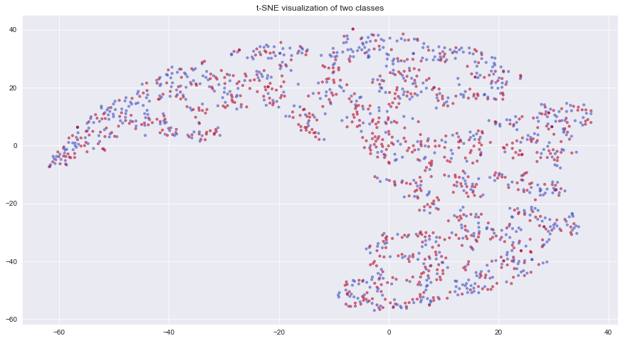

```python
# Create a scatter plot of the t-SNE embedding with colors for each class
plt.figure(figsize=(15, 8))
plt.scatter(X_tsne[:, 0], X_tsne[:, 1], c=y, alpha=0.5, cmap="coolwarm", s=10)
plt.title("t-SNE visualization of two classes")
plt.show()
```

Interpretation: R-squared is a statistical measure that represents the proportion of the variance in the dependent variable that is explained by the independent variables in a regression model.

In some cases, the model may perform so poorly that the variance in the dependent variable that is not explained by the independent variables is greater than the total variance in the dependent variable, resulting in a negative R-squared value. A negative R-squared indicates that the regression model fits worse than a horizontal line, which represents the mean of the dependent variable.

In our particular case, during the data analysis we see that the average scores before 2000 were much higher in average than the ones after 2003 while the feature set is containing features that do not tend to reflect this change: given music of the same genre before and after chosen dates, it would, most probably, have similar music related features (like `key`, `danceability`, etc.) as we see from the TSNE plot and exactly the same one-hot encoded genre features. The only feature that is time-related in this case- `releaseyear` wouldn't help because of our split: model is unable to learn the decreasing trend since no points after the dip were included in to the training set.

Thus we have experienced a concept drift after 2000s and the linear regression model fitted with data before that date could not be used for data after the 2003.

### Task 2 d) BONUS: Are we solving the correct problem? — 14 pts

*Note: This task is not mandatory*

All your efforts so far have assumed that decisions are taken at the "album" level, which is often not the case for bands with multiple albums. In those cases, it could be interesting to predict what is the success of a given band album given the features of the album **and of previous albums**.

1. Create a new dataframe that contains one row per band with more than 1 album. This dataframe should have the same columns as the data provided to you, considering the latest album of the respective band (note that this is determined by the release year of the album, not the date when it was reviewed). Additionally, for each feature considered in Task 2c) 1. (including the one-hot encoded features), create an additional column post-fixed with `_previous` (e.g., `danceability_previous`). These columns should contain the average values for all of the band's previous albums. Also, create a column `score_previous` with the average score of previous albums. Print the number of rows in the dataframe as well as the name of the columns.
2. Train a Gradient Boosting Regressor considering all features created in Task 2d) 1. (note that `score` is the outcome and everything else is a feature, including `score_previous`). Use the 70/30 random train-test split, the default hyperparameters, and report the $R^2$ for the testing set.
3. Can hyperparameter tuning improve your model? Write modular code (i.e., a function) to divide your training data into $N$ folds and perform cross-validation. Experiment tuning two hyperparameters of the Gradient Boosting Regressor: `n_estimators` and `learning_rate`. For each possible combination of the two hyperparameters (see below for the range of values that you should try for each hyperparameter), train your model in a cross-validation setup with $N=20$ folds. Report the mean $R^2$ along with the 90% CI for each scenario.
   - n_estimators $ \in \{ 100, 200, 300, 400\}$
   - learning_rate $ \in \{ 0.1, 0.05, 0.01\}$.

   With the best hyperparameters obtained, train your model with the entire training set and report the $R^2$ on the testing set.

Let's identify artists with multiple albums and filter them.

```python
# Count the number of albums per artist
album_counts = df["artist"].value_counts()

# Get a list of artists with more than one album
artists_with_multiple_albums = album_counts[album_counts > 1].index.tolist()

# Create a new DataFrame with one row per artist
new_df = (
    df[df["artist"].isin(artists_with_multiple_albums)]
    .sort_values(by=["artist", "releaseyear"])
    .reset_index(drop=True)
)
```

```python
# preprocess data and create one-hot variables
new_df = preprocess_genre_column(new_df)
new_df_one_hot = pd.concat([new_df, get_one_hot_genres(new_df)], axis=1)
```

```python
# features to be used in the model
features_selected_for_previous_avg = music_features + one_hot_columns + ["score"]
```

```python
def build_previous_avg_features(df, selected_features):
    # calculate average of all features except for the last row
    assert all(col in df.columns for col in selected_features)
    return pd.DataFrame(df[selected_features].iloc[:-1].mean()).T.add_suffix(
        "_previous"
    )
```

```python
def create_features_per_group(group):
    # calculate average of all features except for the last row
    previous_avg_features = build_previous_avg_features(
        group, selected_features=features_selected_for_previous_avg
    )
    # get the last record within the group
    last_record = (
        group[features_selected_for_previous_avg].iloc[-1:].reset_index(drop=True)
    )
    current_merged = pd.concat([last_record, previous_avg_features], axis=1)
    return current_merged
```

```python
def applyParallel(dfGrouped, func):
    retLst = Parallel(n_jobs=multiprocessing.cpu_count())(
        delayed(func)(group) for name, group in dfGrouped
    )
    return pd.concat(retLst)
```

```python
# create new DataFrame that would be used for GBM training
new_merged = applyParallel(
    new_df_one_hot.groupby("artist"), create_features_per_group
).reset_index(drop=True)
```

It is always a good idea to study the resulting features Let's plot their distributions

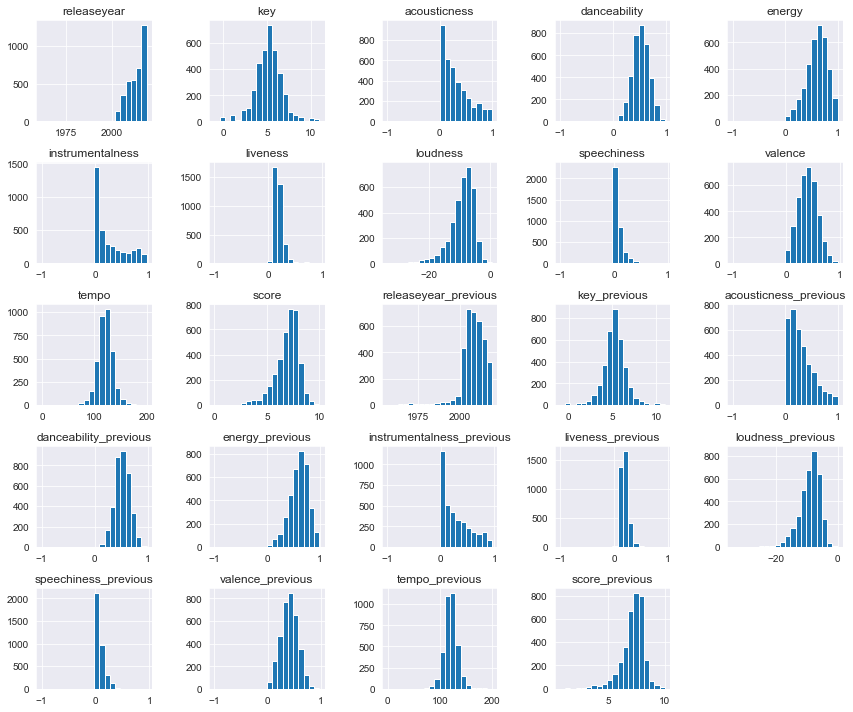

```python
plot_all_distributions(
    new_merged,
    selected_columns=[col for col in new_merged.columns if "onehot" not in col],
)
```

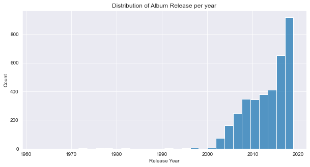

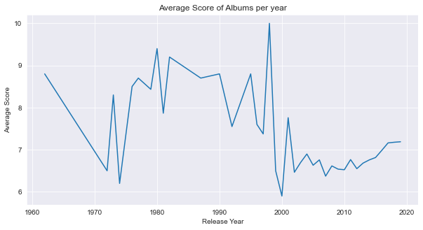

```python
plot_the_distribution(
    new_merged,
)
```

```python
print(f"Number of rows in the new dataset: {new_merged.shape[0]}")
columns_to_print = "\n".join(new_merged.columns.to_list())
print(f"Columns in the new dataset:\n{columns_to_print}")
```

```
Number of rows in the new dataset: 3570
Columns in the new dataset:
releaseyear
key
acousticness
danceability
energy
instrumentalness
liveness
loudness
speechiness
valence
tempo
Electronic_onehot
Experimental_onehot
Folk/Country_onehot
Global_onehot
Jazz_onehot
Metal_onehot
Other_onehot
Pop/R&B_onehot
Rap_onehot
Rock_onehot
score
releaseyear_previous
key_previous
acousticness_previous
danceability_previous
energy_previous
instrumentalness_previous
liveness_previous
loudness_previous
speechiness_previous
valence_previous
tempo_previous
Electronic_onehot_previous
Experimental_onehot_previous
Folk/Country_onehot_previous
Global_onehot_previous
Jazz_onehot_previous
Metal_onehot_previous
Other_onehot_previous
Pop/R&B_onehot_previous
Rap_onehot_previous
Rock_onehot_previous
score_previous
```

## 2. Train a Gradient Boosting Regressor considering all features created in Task 2d) 1. (note that score is the outcome and everything else is a feature, including score_previous).Use the 70/30 random train-test split, the default hyperparameters, and report the $𝑅^2$ for the testing set.

```python
X = new_merged.copy()
y = X.pop("score")

X_train, X_test, y_train, y_test = train_test_split(
    X, y, test_size=0.3, random_state=123
)
```

```python
_ = fit_model(X_train, y_train, X_test, y_test, scale=False, linear_model=False)
```

```
Using GradientBoostingRegressor model
R-squared score: 0.2419062628616765
```

As we can see, the GBM model perform much better than linear model for this task.

```python
_ = fit_model(X_train, y_train, X_test, y_test, scale=True, linear_model=False)
```

```
Using GradientBoostingRegressor model
R-squared score: 0.2432465634479064
```

Scaling features slightly improve the $R^2$ score.

1. Write modular code (i.e., a function) to divide your training data into $N$ folds and perform cross-validation. Experiment tuning two hyperparameters of the Gradient Boosting Regressor: `n_estimators` and `learning_rate`. For each possible combination of the two hyperparameters (see below for the range of values that you should try for each hyperparameter), train your model in a cross-validation setup with $N=20$ folds. Report the mean $R^2$ along with the 90% CI for each scenario.
   - n_estimators { 100, 200, 300, 400}
   - learning_rate { 0.1, 0.05, 0.01}.

With the best hyperparameters obtained, train your model with the entire training set and report the $R^2$ on the testing set.

```python
def gbm_cross_validation_with_params(
    X,
    y,
    parameters,
    n_folds=20,
):
    # Initialize KFold cross-validator
    kf = KFold(n_splits=n_folds, shuffle=True, random_state=42)
    results = []
    n_estimators, learning_rate = (
        parameters["n_estimators"],
        parameters["learning_rate"],
    )

    r2_scores = []
    # Loop through each fold in the KFold
    for train_index, test_index in kf.split(X):
        # Split the data into train and test sets
        X_train, X_test = X[train_index], X[test_index]
        y_train, y_test = y[train_index], y[test_index]

        # Fit the Gradient Boosting Regressor with the current hyperparameters
        gb_regressor = GradientBoostingRegressor(
            n_estimators=n_estimators, learning_rate=learning_rate
        )
        gb_regressor.fit(X_train, y_train)

        # Evaluate the model using R2 score and append to list of scores
        y_pred = gb_regressor.predict(X_test)
        r2_scores.append(r2_score(y_test, y_pred))

    # Calculate the mean and 90% CI for the R2 scores
    mean_r2 = np.mean(r2_scores)
    ci = 1.645 * np.std(r2_scores) / np.sqrt(n_folds)
    lower_ci = mean_r2 - ci
    upper_ci = mean_r2 + ci

    # Add the results to the list of results
    results.append((n_estimators, learning_rate, mean_r2, lower_ci, upper_ci))

    # Convert the list of results to a pandas DataFrame and return it
    results_df = pd.DataFrame(
        results,
        columns=["n_estimators", "learning_rate", "mean_r2", "lower_ci", "upper_ci"],
    )
    return results_df
```

Let's form the grid search space parameters to pass to to our evaluation function.

```python
n_estimators_options = [100, 200, 300, 400]
learning_rate_options = [0.01, 0.05, 0.1]
hyperparameter_options = [
    {"n_estimators": n_estimators, "learning_rate": learning_rate}
    for n_estimators in n_estimators_options
    for learning_rate in learning_rate_options
]
```

```python
hyperparameter_options
```

```
[{'n_estimators': 100, 'learning_rate': 0.01},
 {'n_estimators': 100, 'learning_rate': 0.05},
 {'n_estimators': 100, 'learning_rate': 0.1},
 {'n_estimators': 200, 'learning_rate': 0.01},
 {'n_estimators': 200, 'learning_rate': 0.05},
 {'n_estimators': 200, 'learning_rate': 0.1},
 {'n_estimators': 300, 'learning_rate': 0.01},
 {'n_estimators': 300, 'learning_rate': 0.05},
 {'n_estimators': 300, 'learning_rate': 0.1},
 {'n_estimators': 400, 'learning_rate': 0.01},
 {'n_estimators': 400, 'learning_rate': 0.05},
 {'n_estimators': 400, 'learning_rate': 0.1}]
```

The evaluation function is quite slow so it is better to parallelize it to save some time :)

```python
print("Start the evaluation...")
eval_start = time.perf_counter()
evaluation_results = Parallel(n_jobs=multiprocessing.cpu_count())(
    delayed(gbm_cross_validation_with_params)(
        X.values, y.values, n_folds=20, parameters=p
    )
    for p in hyperparameter_options
)
gbm_report = pd.concat(evaluation_results).reset_index(drop=True)
print(f"Finished! Time elapsed: {time.perf_counter() - eval_start} s.")
```

```
Start the evaluation...
Finished! Time elapsed: 205.47614657599843 s.
```

```python
gbm_report
```

|  | n_estimators | learning_rate | mean_r2 | lower_ci | upper_ci |
| --- | --- | --- | --- | --- | --- |
| 0 | 100 | 0.01 | 0.162055 | 0.144190 | 0.179919 |
| 1 | 100 | 0.05 | 0.192407 | 0.161374 | 0.223440 |
| 2 | 100 | 0.10 | 0.177167 | 0.139838 | 0.214496 |
| 3 | 200 | 0.01 | 0.189454 | 0.165279 | 0.213630 |
| 4 | 200 | 0.05 | 0.186421 | 0.149871 | 0.222971 |
| 5 | 200 | 0.10 | 0.157514 | 0.119077 | 0.195952 |
| 6 | 300 | 0.01 | 0.193626 | 0.166130 | 0.221122 |
| 7 | 300 | 0.05 | 0.177007 | 0.140745 | 0.213268 |
| 8 | 300 | 0.10 | 0.139759 | 0.097765 | 0.181753 |
| 9 | 400 | 0.01 | 0.194702 | 0.165331 | 0.224073 |
| 10 | 400 | 0.05 | 0.169214 | 0.131126 | 0.207303 |
| 11 | 400 | 0.10 | 0.129308 | 0.086301 | 0.172315 |

Let's plot the evaluation results along with the confidence intervals.

```python
def plot_gbm_evaluation_report(df):
    # create figure and axis objects
    fig, ax = plt.subplots(figsize=(15, 5))

    # fill area between lower_ci and upper_ci
    ax.fill_between(df.index, df["lower_ci"], df["upper_ci"], alpha=0.5)

    # plot mean_r2 line
    ax.plot(df.index, df["mean_r2"], color="black")

    # set xticks and labels using n_estimators and learning_rate columns
    xticks = df.index
    xticklabels = [
        f"n_est = {n_estimators}\n\nlr = {learning_rate}"
        for n_estimators, learning_rate in zip(df["n_estimators"], df["learning_rate"])
    ]
    ax.set_xticks(xticks)
    ax.set_xticklabels(xticklabels)

    # set axis labels and title
    ax.set_xlabel("Hyperparameters")
    ax.set_ylabel("R2")
    ax.set_title("R2 vs. Hyperparameters")

    # Find the index of the row with the highest mean_r2 value
    best_index = df["mean_r2"].idxmax()

    # Get the n_estimators and learning_rate values for the best model
    best_n_estimators = df.loc[best_index, "n_estimators"]
    best_learning_rate = df.loc[best_index, "learning_rate"]

    # Add a label to the plot indicating the best mean_r2 value
    plt.annotate(
        "Best mean R2: {:.3f}\n({} n_estimators, {} learning_rate)".format(
            df.loc[best_index, "mean_r2"], best_n_estimators, best_learning_rate
        ),
        xy=(best_index, df.loc[best_index, "mean_r2"]),
        xytext=(best_index, df.loc[best_index, "mean_r2"] + 0.02),
        ha="center",
        arrowprops=dict(facecolor="black", arrowstyle="->"),
        bbox=dict(boxstyle="round,pad=0.5", fc="yellow", alpha=0.5),
    )
    return {"n_estimators": best_n_estimators, "learning_rate": best_learning_rate}
```

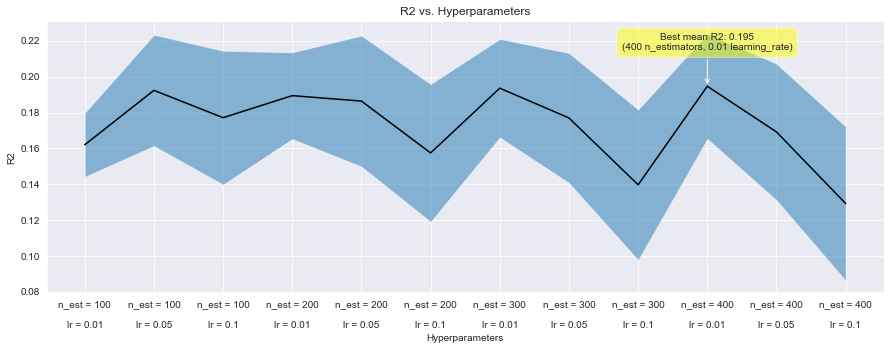

```python
best_params = plot_gbm_evaluation_report(gbm_report)
```

We automatically fit the model with the best parameters below:

```python
# Fit the Gradient Boosting Regressor with the best hyperparameters
gb_regressor = GradientBoostingRegressor(**best_params)
gb_regressor.fit(X_train, y_train)

# Evaluate the model using R2 score and append to list of scores
y_pred = gb_regressor.predict(X_test)
print(
    f"r2 score of the model with the best hyperparameters: {r2_score(y_test, y_pred)}"
)
```

```
r2 score of the model with the best hyperparameters: 0.23899816298501553
```

Surprisingly but the best barameters found during the grid search are showing worse results than the model with default parameters.